# Homework 1 - Report

## 3 - Research Questions

To explore the relationship between antenna design paramaters and the antennas electromagnetic performance, a PCA and Linear Regression Modeling is conducted. But first, some necessary python modules as well as the given data is imported.

```python
import numpy as np
import pandas as pd
import matplotlib.pyplot as plt
```

```python
#import input and output files
#input
input_file = 'data/hw1_input.csv'
input = np.loadtxt(input_file, delimiter=',', skiprows=1)
input_df = pd.read_csv(input_file)
#output real
output_real_file = 'data/hw1_real.csv'
output_real = np.loadtxt(output_real_file, delimiter=',', skiprows=1)
#output imaginary
output_img_file = 'data/hw1_img.csv'
output_img = np.loadtxt(output_img_file, delimiter=',', skiprows=1)
```

```python
#calculate the s11 magnitude
s11_magnitude = (output_real**2 + output_img**2)**0.5

#calculate magnitude in db
s11_db = 20*np.log10(s11_magnitude)
```

### 3.1 Dimensionality Reduction with PCA

To reduce the complexicity of the design space through PCA, the PCA function is imported and used on the scaled input data.

The standard deviation, explained varaince and cumulative variance of each Component is printed. After that, the number of principal components used is set to nine, as the cumulative explained variance reaches 0.9 for nine principal components. The loadings are presented in a table.

```python
#import tools for PCA
from sklearn.decomposition import PCA
from sklearn.preprocessing import StandardScaler
```

```python
# standardize input data
scaler = StandardScaler()
input_scaled = scaler.fit_transform(input)

# PCA
pca = PCA()
principal_comp = pca.fit_transform(input_scaled)

# calculate explained variance and save in dataframe
principal_comp_var = pca.explained_variance_ratio_
principal_comp_var_cum = np.cumsum(principal_comp_var)
principal_comp_std = np.std(principal_comp, axis=0)

principal_comp_info = pd.DataFrame([principal_comp_std, principal_comp_var, principal_comp_var_cum],index=['Standard Deviation','Porportion of Variance','Cumulative Proportion'],columns=[f'PC{i+1}' for i in range(len(input_scaled[0]))])
principal_comp_info
```

|  | PC1 | PC2 | PC3 | PC4 | PC5 | PC6 | PC7 | PC8 | PC9 | PC10 | PC11 |
| --- | --- | --- | --- | --- | --- | --- | --- | --- | --- | --- | --- |
| Standard Deviation | 1.509532 | 1.103536 | 1.048986 | 1.028006 | 1.005275 | 0.986428 | 0.970695 | 0.947711 | 0.898546 | 0.800831 | 0.271318 |
| Porportion of Variance | 0.207153 | 0.110708 | 0.100034 | 0.096072 | 0.091871 | 0.088458 | 0.085659 | 0.081651 | 0.073399 | 0.058303 | 0.006692 |
| Cumulative Proportion | 0.207153 | 0.317862 | 0.417896 | 0.513968 | 0.605839 | 0.694297 | 0.779956 | 0.861607 | 0.935005 | 0.993308 | 1.000000 |

```python
n_comp = 9
# Save loadings in dataframe and print
loadings = pd.DataFrame(pca.components_[:n_comp].T, index=input_df.columns, columns=[f'PC{i+1}' for i in range(len(pca.components_[:n_comp]))])
loadings
```

|  | PC1 | PC2 | PC3 | PC4 | PC5 | PC6 | PC7 | PC8 | PC9 |
| --- | --- | --- | --- | --- | --- | --- | --- | --- | --- |
| length of patch | -0.101327 | -0.315409 | -0.369645 | 0.376883 | -0.409833 | 0.073314 | -0.253331 | -0.454266 | -0.406238 |
| width of patch | 0.624178 | 0.009718 | 0.040766 | 0.039631 | -0.012169 | -0.032326 | 0.000413 | -0.022090 | -0.040157 |
| height of patch | 0.071054 | -0.055716 | 0.620460 | 0.392974 | -0.017701 | 0.069714 | -0.490098 | 0.317943 | -0.216559 |
| height of substrate | 0.624137 | -0.018824 | 0.016441 | 0.076518 | -0.028012 | -0.060565 | 0.002837 | -0.059481 | -0.038186 |
| height of solder resist layer | -0.021049 | -0.266259 | 0.086417 | 0.510652 | 0.124629 | 0.459841 | 0.647199 | 0.110408 | 0.040184 |
| radius of the probe | 0.025997 | -0.002815 | 0.548381 | -0.454397 | -0.218986 | 0.304908 | 0.212779 | -0.491478 | -0.240280 |
| c_pad | -0.054228 | 0.265990 | 0.144827 | 0.177533 | -0.580059 | -0.547579 | 0.429976 | 0.174386 | -0.140321 |
| c_antipad | -0.018720 | 0.559499 | 0.088323 | 0.373926 | -0.127759 | 0.172140 | -0.138146 | -0.415883 | 0.548589 |
| c_probe | 0.039213 | -0.564753 | 0.093131 | -0.151004 | -0.487544 | 0.016285 | -0.102528 | 0.129279 | 0.618694 |
| dielectric constant of substrate | 0.445100 | 0.012829 | -0.256167 | -0.022492 | -0.012254 | 0.027772 | 0.097290 | -0.053226 | 0.031927 |
| dielectric constant of solder resist layer | 0.038422 | 0.350944 | -0.255339 | -0.184975 | -0.420314 | 0.591708 | -0.086813 | 0.460296 | -0.145645 |

The complexicity could be reduced from 11 to 9 through PCA. These 9 principal components explain 93.5 % of the total variance in the design parameter space.

#### Insights from PCA

**PC1:** Principal Component 1 explains the most variance with around 20 % of the total variance. Width of Patch (0.624), Heigth of Substrate (0.624) and the Dielectric constant of substrate (0.445) all have a high positive loading values. That allows the conclusion that variation of these three parameters in general have a strong influence on the S11 magnitude of the antenna. With width and heigth included, it seems as if PC1 decribes a variability that is caused by the dimension/size of the antenna, as well as the substrate material (dielectric constant) and size (height).

**PC2:** The highest loadings for PC2 are from c_antipad (0.559) and c_probe (-0.565). The difference in signs (c_antipad positive, c_probe negative) means that they influence PC2 in different directions, but at a similar absolute value. It can be concluded that c_antipad and c_probe influence the S11 magnitude value in opposite directions. PC2 describes the balance between these two parameters.

**PC3:** PC3's highest loadings come from height of patch (0.62), radius of the probe (0.548) and length of patch (-0.37). Height of patch and radius of the probe both impact PC3 positively, length of patch negatively. The dielectric constants of substrate and solder resist layer also influence this PC significantly (both around -0.25). PC3 is balancing positively influencing geometric parameters (heigth and radius) with negatively influencing material parameters (dielectric constants).

**PC4:** Balancing Height of solder resist (+) and probe radius (-) and influence this principal component in different directions. Solder resist thickness might decrease perfomance while probe radius improves it.

**PC5:** c_pad, c_probe, dielectric layer of solder resist all negatively influence PC5 in the same direction

**PC6:** height of solder resist (+), c_pad (-) and dielectr const of solder resist (+)

**PC7:** height of patch (-), height of solder resist layer (+) and c_pad (+)

**PC8:** length of patch (-), radius of the probe (-) and dielectric constant of solder resist layer (+)

**PC9:** c_antipad (+) and c_probe (+)

### 3.2 Regression Modeling for S11

First, we have to find key frequencies at which we can perform the linear regression. For that, the k lowest S11 magnitudes of the whole output and their respective frequencies are identified. In this case k is set to 9, so the 9 frequency levels with the lowest s11 magnitude are selected and used for linear regression. The key frequency levels are then sorted and include the levels [ 27 28 55 71 85 88 126 155 172]. Other possible approaches for selecting frequencies could have been to select those where several antenna designs reach their lowest s11 magnitudes. This would lead to different frequency levels selected and therefore differing results in the linear regression.

```python
#find smallest magnitude for every design and the corresponding frequency
min_each_row = np.min(s11_magnitude, axis=1)
min_idx_each_row = np.argmin(s11_magnitude, axis=1)

# Get indices of the k lowest magnitudes and their corresponding column indices
num_frequencies = 9
min_idx_lowest = np.argsort(min_each_row)[:num_frequencies]

# saving and sorting the selected frequencies
frequencies = min_idx_each_row[min_idx_lowest]
frequencies_sorted = np.sort(frequencies)

print(frequencies_sorted)
```

```
[ 27  28  55  71  85  88 126 155 172]
```

```python
from sklearn.linear_model import LinearRegression
from sklearn.metrics import mean_squared_error, r2_score
from sklearn.model_selection import train_test_split
```

```python
# Initialize dictionaries to store results
results = {
    'output_real': {'r_squared': [], 'mse': [], 'intercept': [], 'coefficients': []},
    'output_img': {'r_squared': [], 'mse': [], 'intercept': [], 'coefficients': []}
}

pred_real = []
pred_img = []

# split input and output into train and test
in_train, in_test, out_real_train, out_real_test, out_img_train, out_img_test = train_test_split(input_df, output_real, output_img, test_size=0.2, random_state=42)

for freq in frequencies_sorted:

    model_real = LinearRegression(fit_intercept=True)
    model_img = LinearRegression(fit_intercept=True)

    #fit regression model - real
    model_real.fit(in_train, out_real_train[:,freq])
    out_real_pred = model_real.predict(in_test)

    mse_real = mean_squared_error(out_real_test[:,freq], out_real_pred)
    r2_real = r2_score(out_real_test[:,freq], out_real_pred)
    intercept_real = model_real.intercept_
    coefficients_real = model_real.coef_

    #fit regression model - img
    model_img.fit(in_train, out_img_train[:,freq])
    out_img_pred = model_img.predict(in_test)

    mse_img = mean_squared_error(out_img_test[:,freq], out_img_pred)
    r2_img = r2_score(out_img_test[:,freq], out_img_pred)
    intercept_img = model_img.intercept_
    coefficients_img = model_img.coef_

    #save results/metrics for each regression model
    pred_real.append(out_real_pred)
    pred_img.append(out_img_pred)
    results['output_real']['r_squared'].append(r2_real)
    results['output_real']['mse'].append(mse_real)
    results['output_real']['intercept'].append(intercept_real)
    results['output_real']['coefficients'].append(coefficients_real)
    results['output_img']['r_squared'].append(r2_img)
    results['output_img']['mse'].append(mse_img)
    results['output_img']['intercept'].append(intercept_img)
    results['output_img']['coefficients'].append(coefficients_img)
```

```python
for i in range(len(frequencies)):
    # Retrieve the MSE and R-squared values for both outputs at the current frequency level
    mse_real = results['output_real']['mse'][i]
    r_squared_real = results['output_real']['r_squared'][i]

    mse_img = results['output_img']['mse'][i]
    r_squared_img = results['output_img']['r_squared'][i]

    # Print the results for this frequency level
    print(f"Frequency Level {frequencies_sorted[i]}:")
    print(f"  Real - MSE: {mse_real}, R-squared: {r_squared_real}")
    print(f"  Imaginary - MSE: {mse_img}, R-squared: {r_squared_img}")
    print()
```

```
Frequency Level 27:
  Real - MSE: 0.07157992116928036, R-squared: 0.8743885433589881
  Imaginary - MSE: 0.12144958578353267, R-squared: 0.06569558360784522

Frequency Level 28:
  Real - MSE: 0.07170412534658013, R-squared: 0.8737386048918218
  Imaginary - MSE: 0.11931661076115357, R-squared: 0.06962142281317507

Frequency Level 55:
  Real - MSE: 0.07866735004148381, R-squared: 0.8408291992291774
  Imaginary - MSE: 0.10245373582905477, R-squared: 0.09871642691994376

Frequency Level 71:
  Real - MSE: 0.08566890061748429, R-squared: 0.8220131887483644
  Imaginary - MSE: 0.08707774623227489, R-squared: 0.038466390915905535

Frequency Level 85:
  Real - MSE: 0.05717502063315684, R-squared: 0.8757819566695508
  Imaginary - MSE: 0.07556721442109758, R-squared: 0.16955100693470304

Frequency Level 88:
  Real - MSE: 0.05720008549831748, R-squared: 0.8744063889246042
  Imaginary - MSE: 0.07081538335553929, R-squared: 0.22001555261232086

Frequency Level 126:
  Real - MSE: 0.07847227695507127, R-squared: 0.7936228572132201
  Imaginary - MSE: 0.07698955006043791, R-squared: 0.26352534755379386

Frequency Level 155:
  Real - MSE: 0.07212699243176837, R-squared: 0.8157979108499123
  Imaginary - MSE: 0.08733818689159746, R-squared: 0.13818139420155517

Frequency Level 172:
  Real - MSE: 0.08624070856074144, R-squared: 0.7926742925200861
  Imaginary - MSE: 0.0660874529240054, R-squared: 0.2388565478499023
```

For better interpretability and understanding, the predicted s11 values (real and imaginary) are plotted against the test sets. This helps identifying specific weaknesses of the regression models apart from just high or low R-squared and MSE values.

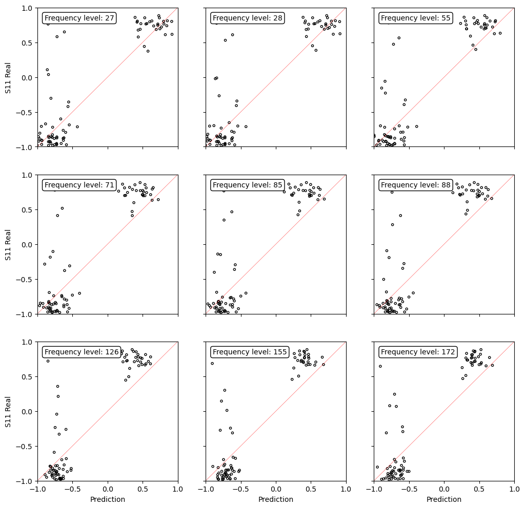

```python
#Plotting Linear Regression Predictions - Real s11 component

fig, axs = plt.subplots(3, 3,figsize=(12,12))

#scatter-plot actual value over predicted values
for i,ax in enumerate(axs.flat):
    if(i>=len(frequencies)):
        break
    ax.scatter(pred_real[i],out_real_test[:,i],color='black',marker='.',facecolors='none')
    ax.axline((0, 0), slope=1,color='red',linewidth=0.3)
    ax.text(0.05, 0.95, f'Frequency level: {frequencies_sorted[i]}',
            transform=ax.transAxes, verticalalignment='top', horizontalalignment='left',
            bbox=dict(facecolor='white', edgecolor='black', boxstyle='round,pad=0.3'))

# set axis properties
for ax in axs.flat:
    ax.set(xlabel='Prediction', ylabel='S11 Real')
    ax.set_xlim([-1, 1])
    ax.set_ylim([-1, 1])
    ax.set_xticks(np.arange(-1, 1.1, 0.5))
    ax.set_yticks(np.arange(-1, 1.1, 0.5))
    ax.label_outer()
```

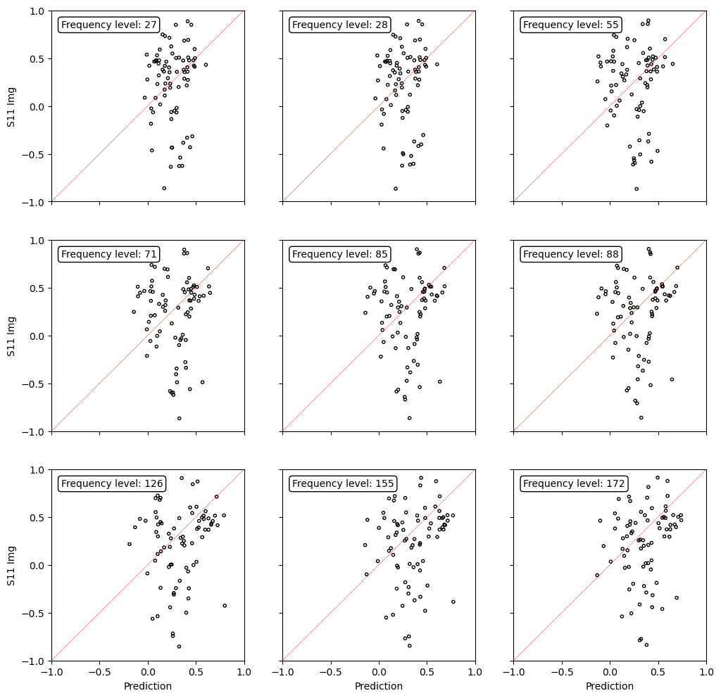

```python
#Plotting Linear Regression Predictions - Imaginary s11 component

fig, axs = plt.subplots(3, 3,figsize=(12,12))

#scatter-plot actual value over predicted values
for i,ax in enumerate(axs.flat):
    if(i>=len(frequencies)):
        break
    ax.scatter(pred_img[i],out_img_test[:,i],color='black',marker='.',facecolors='none')
    ax.axline((0, 0), slope=1,color='red',linewidth=0.3)
    ax.text(0.05, 0.95, f'Frequency level: {frequencies_sorted[i]}',
            transform=ax.transAxes, verticalalignment='top', horizontalalignment='left',
            bbox=dict(facecolor='white', edgecolor='black', boxstyle='round,pad=0.3'))


# set axis properties
for ax in axs.flat:
    ax.set(xlabel='Prediction', ylabel='S11 Img')
    ax.set_xlim([-1, 1])
    ax.set_ylim([-1, 1])
    ax.set_xticks(np.arange(-1, 1.1, 0.5))
    ax.set_yticks(np.arange(-1, 1.1, 0.5))
    ax.label_outer()
```

**Real Component:** For the predicition of the real component, there are two clusters of points - at s11 values close to -1 and 1 - for each freach frequency. The regression models are good at predicting wether the real component of the s11 is positive or negative. There are no data points in the center of the plot, where both the measured and the predicted value would be close to 0. The amount of points where a the real component of the s11 is predicted to be a value close to 0 (--> low magnitude, good antenna performance) is small in general. If the real component is low in reality, the prediction of the linear regression model is in the range of -0.5 to -1. Looking at frequency level 126 for example, for positive actual s11 components, the predicted value is always too small (all data points left of the red y=x line). For negative s11 components <-0.5, the predicted value is generally too large (closer to 0), as almost all data points are located on the right of the y=x line.

**Imaginary Component:** For the imaginary component can be said that there are a lot of points not closely aligned with the perfect prediction line (red line y=x) for each frequency level, meaning that a lot of predicted values don't match the actual values. There are more cases of good predictions around a imaginary s11 component around zero though (compared to the regression for the real component). For the lower frequency levels, almost all predicted values fall in the range of 0 to 0.5 with close to no negative values. The higher the frequency level, the bigger the range of predicted imaginary values (around -0.25 to 0.8). The actual imaginary s11 values of the test range between -1 to 1. This discrepancy could imply systemic biases.

**Conclusion:** Generally, the regression models used predicted high absolute values for the real component for almost all frequencies. Low values, meaning low magnitudes and good antenna performance, are rarely - and never correctly - predicted. The regression models for the imaginary component are better at correctly predicting low values, but almost completely fail at differentiating between positive and negative values. Additionaly, a varying spread depending on the frequency level implies that there might be different model parameters needed for each frequency.

### 3.3 Model Performance and Interpretability

**Comparison and Limitations of PCA and Linear Regression**

The PCA is primarily used to just simplify the data without predicting. In this case, the dimension was reduced from 11 design parameters originally to 9 principal components that capture around 93.5 % of the total variance. Due to the complexity of the electromagnetic behavior and the still high number of principal components, a prediction on the basis of PCA is difficult. It would be possible to calculate a correlation matrix for the principal components with the output, but a focus on a select number of frequencies might be necessary for interpertability.

As seen in the plots, the linear regression models were not fully able to capture the relationship between in- and outputs. The reason for that could be a more complex nonlinear relationship between the in- and outputs, which a simple linear regression model can not cover.

It would be possible to use the PCA results in a regression model in order to reduce effects of multicollinearity among the input features. In addition to that, another, nonlinear regression approach could be chosen to better understand and predict the relationship between design parameters and the antennas performance.

These more complex regression approaches combined with PCA could be used to more reliably predict s11 values and identify more patterns of the geometries influence on the antenna's electromagnetic behavior.

## Academic Integrity

GenAI was used as an aid in the coding process for this homework, the prompts used are summarized here: [GenAI Prompts](https://bu-ie-582.github.io/fall-24-hannesknieke/hw1/GenAI_Prompts_hw1.pdf)